# Los_Angeles_Inspection_exploratory_data_analysis

```python
# Required Packages
import pandas as pd
import numpy as np
import json

# Plots

import seaborn as sns
import matplotlib.pyplot as plt
from matplotlib.patches import Ellipse, Polygon
import matplotlib.gridspec as gridspec

# sns setting
sns.set_context("paper", rc={"font.size":12,"axes.titlesize":14,"axes.labelsize":12})
sns.set_style("whitegrid")

# plt setting
plt.style.use('seaborn-whitegrid')
plt.rcParams['axes.labelsize'] = 14
plt.rcParams['xtick.labelsize'] = 12
plt.rcParams['ytick.labelsize'] = 12
plt.rcParams['text.color'] = 'k'
%matplotlib inline
import warnings
warnings.filterwarnings("ignore")
```

- Los Angeles County Restaurant and Market Violations and Inspections
- Loading Datasets
  - Violations Dataset
  - Inspection Result Dataset
  - Merged Dataset
- Initial Analysis
  - Dates with the most Number of Violations
  - Restaurant Owners with the most number of Violations
  - Facilities with the Most Violations
  - Programs with the Most Violations
  - Cities with the Most Violations
  - Service Description
  - The Number of Violations by High-Score and Low-Score Facilities
  - The Number of Violations by Each Grades
  - Violation Status
  - The Most Described Violations
  - Program Element Description
  - A Deeper look into Violation by each Facility

# Los Angeles County Restaurant and Market Violations and Inspections

In this article, we use a dataset contains Environmental Health Violations for Restaurants and Markets in Los Angeles County. This dataset can be found [here](https://data.lacounty.gov/Health/LOS-ANGELES-COUNTY-RESTAURANT-AND-MARKET-VIOLATION/8jyd-4pv9) and [here](https://data.lacounty.gov/Health/LOS-ANGELES-COUNTY-RESTAURANT-AND-MARKET-INSPECTIO/6ni6-h5kp).

Los Angeles County Environmental Health is responsible for checking food violations for all unincorporated areas and 85 of the 88 cities in the County. This dataset does not include Pasadena, Long Beach or Vernon (each has its own city health department).

# Loading Datasets

The data that has been processed before.

```python
Violations_df = pd.read_csv('Data/LA/Clean_Violations_df.csv')
Inspections_df = pd.read_csv('Data/LA/Clean_Inspections_df.csv')
Data  = pd.read_csv('Data/LA/Data_Inspections_Violations_df.csv')
Violation_Dictionary_df  = pd.read_csv('Data/LA/Violation_Dictionary_df.csv')
```

## Violations Dataset

Each row represents one health code violation. All rows with the same Serial Number are part of the same inspection. The Serial Number is the primary key to review the inspection grade (Inspection Result dataset)

```python
Violations_df.head().style.hide_index()
```

| SERIAL NUMBER | VIOLATION STATUS | VIOLATION CODE | VIOLATION DESCRIPTION | POINTS |
| --- | --- | --- | --- | --- |
| DA000211Z | OUT OF COMPLIANCE | F006 | # 06. Adequate handwashing facilities supplied & accessible | 2.000000 |
| DA000211Z | OUT OF COMPLIANCE | F044 | # 44. Floors, walls and ceilings: properly built, maintained in good repair and clean | 1.000000 |
| DA000211Z | OUT OF COMPLIANCE | F014 | # 14. Food contact surfaces: clean and sanitized | 2.000000 |
| DA000211Z | OUT OF COMPLIANCE | F029 | # 29. Toxic substances properly identified, stored, used | 1.000000 |
| DA000211Z | OUT OF COMPLIANCE | F035 | # 35. Equipment/Utensils - approved; installed; clean; good repair, capacity | 1.000000 |

## Inspection Result Dataset

Each row represents one inspection result. The Serial Number is the primary key to access/review the violations (Violations Dataset) associated with a particular inspection.

```python
Inspections_df.head().style.hide_index()
```

| ACTIVITY DATE | OWNER ID | OWNER NAME | FACILITY ID | FACILITY NAME | RECORD ID | PROGRAM NAME | PROGRAM STATUS | PROGRAM ELEMENT (PE) | PE DESCRIPTION | FACILITY ADDRESS | FACILITY CITY | FACILITY STATE | FACILITY ZIP | SERVICE CODE | SERVICE DESCRIPTION | SCORE | GRADE | SERIAL NUMBER | EMPLOYEE ID | Location |
| --- | --- | --- | --- | --- | --- | --- | --- | --- | --- | --- | --- | --- | --- | --- | --- | --- | --- | --- | --- | --- |
| 2017-06-02 | OW0030652 | ROMERO, JUAN | FA0021745 | EL ZIPOTE PUPUSERIA | PR0047587 | EL ZIPOTE PUPUSERIA | ACTIVE | 1632 | RESTAURANT (0-30) SEATS HIGH RISK | 1111 W WASHINGTON BLVD STE H | MONTEBELLO | CA | 90640 | 1 | ROUTINE INSPECTION | 91 | A | DAXE7ACTS | EE0000773 | nan |
| 2017-06-05 | OW0025119 | MORNING SUN INC. | FA0008772 | CHINA GATE | PR0029024 | CHINA GATE | ACTIVE | 1632 | RESTAURANT (0-30) SEATS HIGH RISK | 11814 S WILMINGTON AVE | LOS ANGELES | CA | 90059 | 1 | ROUTINE INSPECTION | 94 | A | DADMCPXSY | EE0000927 | nan |
| 2017-06-07 | OW0007353 | CHEN, CHAO SHU | FA0070050 | SAN HING | PR0004325 | SAN HING | INACTIVE | 1632 | RESTAURANT (0-30) SEATS HIGH RISK | 11136 PALMS BLVD | LOS ANGELES | CA | 90034 | 1 | ROUTINE INSPECTION | 96 | A | DAJMZ6U86 | EE0000911 | POINT (-118.422231 34.01925) |
| 2017-06-12 | OW0100197 | SBARRO, LLC | FA0032188 | SBARRO | PR0018712 | SBARRO | ACTIVE | 1631 | RESTAURANT (0-30) SEATS MODERATE RISK | 3650 W MLK BLVD # FC-10 | LOS ANGELES | CA | 90008 | 1 | ROUTINE INSPECTION | 90 | A | DAMPB9559 | EE0000176 | nan |
| 2017-06-15 | OW0028751 | PO SOKHOR | FA0023039 | LUCKY DONUTS | PR0038158 | LUCKY DONUTS | ACTIVE | 1631 | RESTAURANT (0-30) SEATS MODERATE RISK | 14700 S WESTERN AVE STE # 106 | GARDENA | CA | 90249 | 1 | ROUTINE INSPECTION | 93 | A | DAAG0SNGQ | EE0000062 | nan |

## Merged Dataset

```python
Data.head().style.hide_index()
```

| Activity Date | Owner ID | Owner Name | Facility ID | Facility Name | Record ID | Program Name | Program Status | Program Element (PE) | Facility Address | Facility City | Facility State | Facility Zip | Service Code | Service Description | Score | Grade | Serial Number | Employee ID | Location | Violation Status | Violation Code | Violation Description | Points | PE_Type | PE_Seats | PE_Risk |
| --- | --- | --- | --- | --- | --- | --- | --- | --- | --- | --- | --- | --- | --- | --- | --- | --- | --- | --- | --- | --- | --- | --- | --- | --- | --- | --- |
| 2017-06-02 | OW0030652 | ROMERO, JUAN | FA0021745 | EL ZIPOTE PUPUSERIA | PR0047587 | EL ZIPOTE PUPUSERIA | ACTIVE | 1632.000000 | 1111 W WASHINGTON BLVD STE H | MONTEBELLO | CA | 90640.000000 | 1.000000 | ROUTINE INSPECTION | 91.000000 | A | DAXE7ACTS | EE0000773 | nan | OUT OF COMPLIANCE | F036 | # 36. Equipment, utensils and linens: storage and use | 1.000000 | Restaurant | 0-30 SQ. FT. | High Risk |
| 2017-06-02 | OW0030652 | ROMERO, JUAN | FA0021745 | EL ZIPOTE PUPUSERIA | PR0047587 | EL ZIPOTE PUPUSERIA | ACTIVE | 1632.000000 | 1111 W WASHINGTON BLVD STE H | MONTEBELLO | CA | 90640.000000 | 1.000000 | ROUTINE INSPECTION | 91.000000 | A | DAXE7ACTS | EE0000773 | nan | OUT OF COMPLIANCE | F004 | # 04. Proper eating, drinking, or tobacco use | 2.000000 | Restaurant | 0-30 SQ. FT. | High Risk |
| 2017-06-02 | OW0030652 | ROMERO, JUAN | FA0021745 | EL ZIPOTE PUPUSERIA | PR0047587 | EL ZIPOTE PUPUSERIA | ACTIVE | 1632.000000 | 1111 W WASHINGTON BLVD STE H | MONTEBELLO | CA | 90640.000000 | 1.000000 | ROUTINE INSPECTION | 91.000000 | A | DAXE7ACTS | EE0000773 | nan | OUT OF COMPLIANCE | F023 | # 23. No rodents, insects, birds, or animals | 2.000000 | Restaurant | 0-30 SQ. FT. | High Risk |
| 2017-06-02 | OW0030652 | ROMERO, JUAN | FA0021745 | EL ZIPOTE PUPUSERIA | PR0047587 | EL ZIPOTE PUPUSERIA | ACTIVE | 1632.000000 | 1111 W WASHINGTON BLVD STE H | MONTEBELLO | CA | 90640.000000 | 1.000000 | ROUTINE INSPECTION | 91.000000 | A | DAXE7ACTS | EE0000773 | nan | OUT OF COMPLIANCE | F005 | # 05. Hands clean and properly washed; gloves used properly | 4.000000 | Restaurant | 0-30 SQ. FT. | High Risk |
| 2017-06-05 | OW0025119 | MORNING SUN INC. | FA0008772 | CHINA GATE | PR0029024 | CHINA GATE | ACTIVE | 1632.000000 | 11814 S WILMINGTON AVE | LOS ANGELES | CA | 90059.000000 | 1.000000 | ROUTINE INSPECTION | 94.000000 | A | DADMCPXSY | EE0000927 | nan | OUT OF COMPLIANCE | F039 | # 39. Wiping cloths: properly used and stored | 1.000000 | Restaurant | 0-30 SQ. FT. | High Risk |

# Exploratory Data Analysis

First off, note that our dataset has the following columns.

```python
Data.columns
```

```
Index(['Activity Date', 'Owner ID', 'Owner Name', 'Facility ID',
       'Facility Name', 'Record ID', 'Program Name', 'Program Status',
       'Program Element (PE)', 'Facility Address', 'Facility City',
       'Facility State', 'Facility Zip', 'Service Code', 'Service Description',
       'Score', 'Grade', 'Serial Number', 'Employee ID', 'Location',
       'Violation Status', 'Violation Code', 'Violation Description', 'Points',
       'PE_Type', 'PE_Seats', 'PE_Risk'],
      dtype='object')
```

## Dates with the most Number of Violations

```python
Activity = pd.DataFrame(Data.groupby('Activity Date')['Violation Code'].count())
Activity.columns = ['Count']
Activity[Activity['Count'] >2400 ].T
```

| Activity Date | 2018-01-16 | 2018-03-21 | 2018-07-17 | 2018-07-24 | 2018-07-25 | 2018-08-08 | 2018-09-18 | 2018-09-25 | 2018-09-26 | 2018-10-03 | ... | 2019-08-28 | 2019-09-10 | 2019-09-18 | 2019-09-24 | 2019-09-25 | 2019-10-09 | 2019-10-29 | 2019-11-19 | 2019-11-20 | 2019-12-04 |
| --- | --- | --- | --- | --- | --- | --- | --- | --- | --- | --- | --- | --- | --- | --- | --- | --- | --- | --- | --- | --- | --- |
| Count | 2467 | 2401 | 2560 | 2501 | 2406 | 2497 | 2505 | 2605 | 2546 | 2653 | ... | 2439 | 2487 | 2470 | 2728 | 2410 | 2628 | 2439 | 2421 | 2434 | 2465 |

1 rows × 39 columns

```python
Activity[Activity['Count'] == Activity.max()[0]].index[0]
```

```
'2019-01-23'
```

We can see that the highest number of violations happened on **January 23, 2019**.

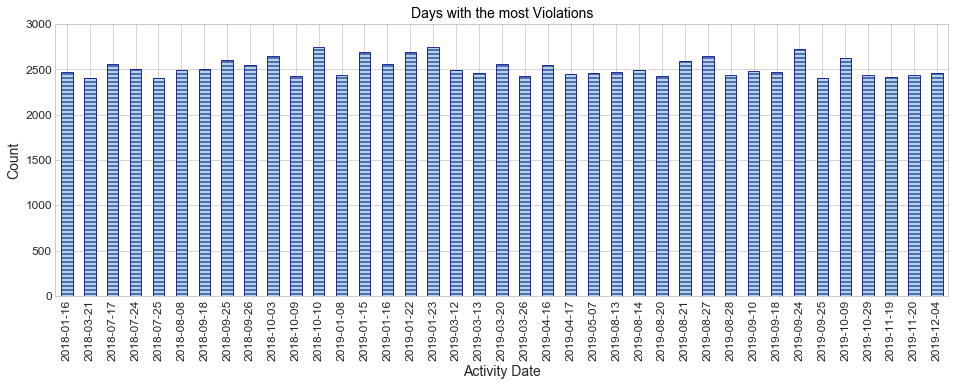

```python
fig, ax = plt.subplots(nrows=1, ncols=1, figsize=(16, 5), sharex=False)
_ = Activity[Activity['Count'] >2400 ].plot.bar(rot=90,ax=ax, legend=False,
                                                color=sns.light_palette('lightBlue', reverse=True), edgecolor='Navy',
                                                hatch = '---')
_ = ax.set_title('Days with the most Violations')
_ = ax.set_ylim([0, 3e3])
_ = ax.set_xlabel('Activity Date')
_ = ax.set_ylabel('Count')
```

In particular, for the hightest number of violations, we have

```python
Activity_Violation = pd.DataFrame(Data.groupby(['Activity Date','Violation Code'])['Violation Code'].count())
Activity_Violation.columns = ['Count']
list = Activity[Activity['Count'] == Activity['Count'].max()].index
temp = Activity_Violation.loc[list]
temp = temp.reset_index(drop=False).drop(columns ='Activity Date')
temp.T
```

|  | 0 | 1 | 2 | 3 | 4 | 5 | 6 | 7 | 8 | 9 | ... | 35 | 36 | 37 | 38 | 39 | 40 | 41 | 42 | 43 | 44 |
| --- | --- | --- | --- | --- | --- | --- | --- | --- | --- | --- | --- | --- | --- | --- | --- | --- | --- | --- | --- | --- | --- |
| Violation Code | F004 | F005 | F006 | F007 | F008 | F009 | F011 | F013 | F014 | F016 | ... | F047 | F048 | F049 | F050 | F052 | F053 | F054 | F055 | F057 | F058 |
| Count | 11 | 11 | 115 | 105 | 15 | 27 | 1 | 13 | 114 | 5 | ... | 4 | 23 | 33 | 14 | 35 | 41 | 7 | 21 | 2 | 4 |

2 rows × 45 columns

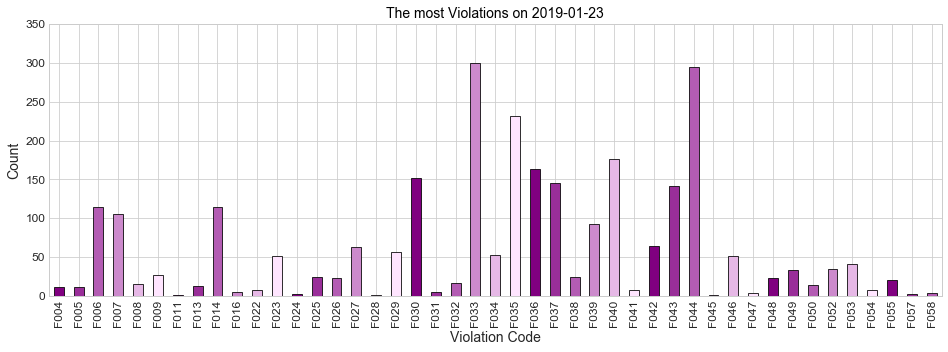

```python
fig, ax = plt.subplots(nrows=1, ncols=1, figsize=(16, 5), sharex=False)
_ = temp.plot.bar(rot=90,ax=ax, x='Violation Code', y='Count', legend=False,
                  color=sns.light_palette("purple", reverse=True), edgecolor="k")
_ = ax.set_title('The most Violations on %s' % list.tolist()[0])
_ = ax.set_ylim([0, 350])
# _ = ax.set_yscale('log')
_ = ax.set_xlabel('Violation Code')
_ = ax.set_ylabel('Count')
```

The most violations on this day are:

```python
mylist=temp.sort_values('Count', ascending=False).head(3)['Violation Code'].tolist()
Violation_Dictionary_df.loc[Violation_Dictionary_df['Violation Code'].isin(mylist)].style.hide_index()
```

| Violation Code | Violation Description |
| --- | --- |
| F044 | # 44. Floors, walls and ceilings: properly built, maintained in good repair and clean |
| F035 | # 35. Equipment/Utensils - approved; installed; clean; good repair, capacity |
| F033 | # 33. Nonfood-contact surfaces clean and in good repair |

## Restaurant Owners with the most number of Violations

```python
Owners= pd.DataFrame(Data[Data['Owner ID'].isna()==False].groupby('Owner ID')['Violation Code'].count())
Owners.columns = ['Count']
Owners=Owners.sort_values(by='Count', ascending=False)
Owners[Owners['Count'] >1.5e3].T
```

| Owner ID | OW0029458 | OW0038181 | OW0033938 | OW0010868 | OW0012108 | OW0033717 | OW0004937 | OW0034460 | OW0007608 | OW0027458 | OW0038850 | OW0012926 | OW0033830 | OW0009661 | OW0038349 | OW0002029 |
| --- | --- | --- | --- | --- | --- | --- | --- | --- | --- | --- | --- | --- | --- | --- | --- | --- |
| Count | 7348 | 5440 | 3461 | 2803 | 2469 | 2213 | 2210 | 2143 | 2130 | 2076 | 1847 | 1817 | 1624 | 1607 | 1574 | 1542 |

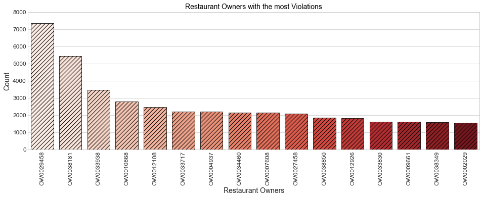

```python
fig, ax = plt.subplots(nrows=1, ncols=1, figsize=(16, 5), sharex=False)

_ = sns.barplot(ax = ax, x='Owner ID', y='Count', palette='Reds',
                edgecolor='k',  hatch="///", data= Owners[Owners['Count'] >1.5e3].reset_index())
# _ = Owners[Owners['Count'] >1.5e3].plot.bar(rot=90,ax=ax, legend=False, color="#34495e", edgecolor="k")
_ = ax.set_xticklabels(ax.get_xticklabels(), rotation=90)
_ = ax.set_title('Restaurant Owners with the most Violations')
_ = ax.set_ylim([0, 8e3])
_ = ax.set_xlabel('Restaurant Owners')
_ = ax.set_ylabel('Count')
```

In particular,

```python
Owners_Violation  = pd.DataFrame(Data.groupby(['Owner ID','Violation Code'])['Violation Code'].count())
Owners_Violation.columns = ['Count']
list = Owners[Owners['Count'] == Owners['Count'].max()].index
temp = Owners_Violation.loc[list]
temp = temp.reset_index(drop=False).drop(columns ='Owner ID')
temp.T
```

|  | 0 | 1 | 2 | 3 | 4 | 5 | 6 | 7 | 8 | 9 | ... | 37 | 38 | 39 | 40 | 41 | 42 | 43 | 44 | 45 | 46 |
| --- | --- | --- | --- | --- | --- | --- | --- | --- | --- | --- | --- | --- | --- | --- | --- | --- | --- | --- | --- | --- | --- |
| Violation Code | F001 | F004 | F005 | F006 | F007 | F008 | F009 | F011 | F013 | F014 | ... | F048 | F049 | F050 | F052 | F053 | F054 | F055 | F058 | W019 | W020 |
| Count | 7 | 10 | 17 | 185 | 303 | 14 | 5 | 3 | 22 | 169 | ... | 34 | 70 | 7 | 20 | 95 | 3 | 31 | 9 | 1 | 1 |

2 rows × 47 columns

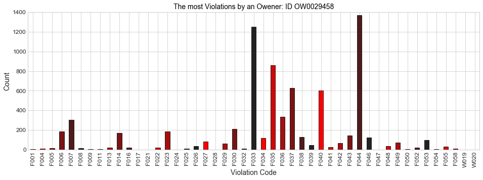

```python
fig, ax = plt.subplots(nrows=1, ncols=1, figsize=(16, 5), sharex=False)
_ = temp.plot.bar(rot=90,ax=ax, x='Violation Code', y='Count', legend=False,
                  color=sns.dark_palette("red", reverse=True), edgecolor="k")
_ = ax.set_title('The most Violations by an Owener: ID %s' % list.tolist()[0])
_ = ax.set_ylim([0, 1.4e3])
_ = ax.set_xlabel('Violation Code')
_ = ax.set_ylabel('Count')
```

The most violations by this owner are:

```python
mylist=temp.sort_values('Count', ascending=False).head(3)['Violation Code'].tolist()
Violation_Dictionary_df.loc[Violation_Dictionary_df['Violation Code'].isin(mylist)].style.hide_index()
```

| Violation Code | Violation Description |
| --- | --- |
| F044 | # 44. Floors, walls and ceilings: properly built, maintained in good repair and clean |
| F035 | # 35. Equipment/Utensils - approved; installed; clean; good repair, capacity |
| F033 | # 33. Nonfood-contact surfaces clean and in good repair |

## Facilities with the Most Violations

```python
Facilities = pd.DataFrame(Data[Data['Facility Name'].isna()==False].groupby('Facility Name')['Violation Code'].count())
Facilities.columns = ['Count']
Facilities = Facilities.sort_values(by='Count', ascending=False)
Facilities[Facilities['Count'] >6e2].T
```

| Facility Name | SUBWAY | DOMINO'S PIZZA | WABA GRILL | EL SUPER | EL POLLO LOCO | DODGER STADIUM | JERSEY MIKE'S SUBS | WHOLE FOODS MARKET | THE COFFEE BEAN & TEA LEAF | 7-ELEVEN | ... | SPROUTS FARMERS MARKET | KENTUCKY FRIED CHICKEN | ONO HAWAIIAN BBQ | LA COLISEUM | YOGURTLAND | WINGSTOP | BASKIN ROBBINS | WETZEL'S PRETZELS | MCDONALD'S | SUPERIOR SUPER WAREHOUSE |
| --- | --- | --- | --- | --- | --- | --- | --- | --- | --- | --- | --- | --- | --- | --- | --- | --- | --- | --- | --- | --- | --- |
| Count | 1819 | 1524 | 1523 | 1479 | 1452 | 1402 | 1382 | 1260 | 1151 | 990 | ... | 816 | 802 | 792 | 731 | 731 | 657 | 651 | 645 | 605 | 604 |

1 rows × 26 columns

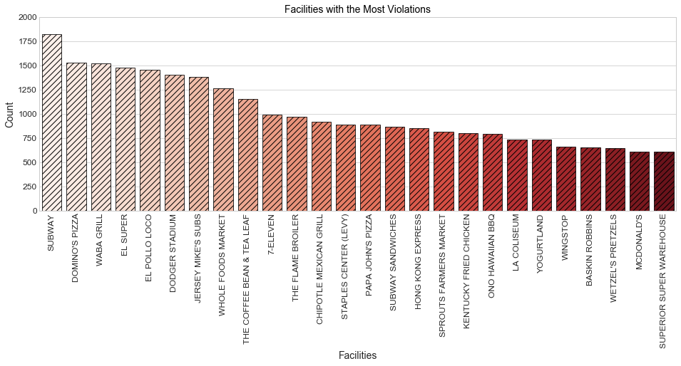

```python
fig, ax = plt.subplots(nrows=1, ncols=1, figsize=(16, 5), sharex=False)
_ = sns.barplot(ax = ax, x='Facility Name', y='Count', palette='Reds',
                edgecolor='k',  hatch="///", data= Facilities[Facilities['Count'] >6e2].reset_index())

# _ = Facilities[Facilities['Count'] >6e2].plot.bar(rot=90,ax=ax, legend=False,
#                                               color='#e74c3c', edgecolor='k')
_ = ax.set_xticklabels(ax.get_xticklabels(), rotation=90)
_ = ax.set_title('Facilities with the Most Violations')
_ = ax.set_ylim([0, 2e3])
_ = ax.set_xlabel('Facilities')
_ = ax.set_ylabel('Count')
```

```python
Facilities_Violation  = pd.DataFrame(Data.groupby(['Facility Name','Violation Code'])['Violation Code'].count())
Facilities_Violation.columns = ['Count']
list = Facilities[Facilities['Count'] == Facilities['Count'].max()].index
temp = Facilities_Violation.loc[list]
temp = temp.reset_index(drop=False).drop(columns ='Facility Name')
temp.T
```

|  | 0 | 1 | 2 | 3 | 4 | 5 | 6 | 7 | 8 | 9 | ... | 28 | 29 | 30 | 31 | 32 | 33 | 34 | 35 | 36 | 37 |
| --- | --- | --- | --- | --- | --- | --- | --- | --- | --- | --- | --- | --- | --- | --- | --- | --- | --- | --- | --- | --- | --- |
| Violation Code | F001 | F004 | F005 | F006 | F007 | F008 | F009 | F011 | F013 | F014 | ... | F043 | F044 | F046 | F048 | F049 | F050 | F052 | F053 | F054 | F055 |
| Count | 1 | 12 | 14 | 51 | 161 | 1 | 6 | 3 | 2 | 112 | ... | 74 | 232 | 87 | 22 | 29 | 4 | 61 | 28 | 4 | 15 |

2 rows × 38 columns

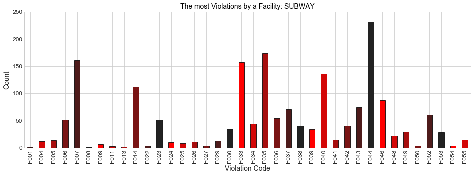

```python
fig, ax = plt.subplots(nrows=1, ncols=1, figsize=(16, 5), sharex=False)
_ = temp.plot.bar(rot=90,ax=ax, x='Violation Code', y='Count', legend=False,
                  color=sns.dark_palette("red", reverse=True), edgecolor="k")
_ = ax.set_title('The most Violations by a Facility: %s' % list.tolist()[0])
_ = ax.set_ylim([0, 250])
_ = ax.set_xlabel('Violation Code')
_ = ax.set_ylabel('Count')
```

The most violations by this facility are:

```python
mylist=temp.sort_values('Count', ascending=False).head(3)['Violation Code'].tolist()
Violation_Dictionary_df.loc[Violation_Dictionary_df['Violation Code'].isin(mylist)].style.hide_index()
```

| Violation Code | Violation Description |
| --- | --- |
| F044 | # 44. Floors, walls and ceilings: properly built, maintained in good repair and clean |
| F035 | # 35. Equipment/Utensils - approved; installed; clean; good repair, capacity |
| F007 | # 07. Proper hot and cold holding temperatures |

## Programs with the Most Violations

```python
Programs = pd.DataFrame(Data[Data['Program Name'].isna()==False].groupby('Program Name')['Violation Code'].count())
Programs.columns = ['Count']
Programs.sort_values(by='Count', ascending=False, inplace = True)
Programs[Programs['Count'] >8e2].T
```

| Program Name | SUBWAY | WABA GRILL | EL POLLO LOCO | DOMINO'S PIZZA | JERSEY MIKE'S SUBS | JACK IN THE BOX | MCDONALD'S | THE FLAME BROILER | 7-ELEVEN | THE COFFEE BEAN & TEA LEAF | PAPA JOHN'S PIZZA | SUBWAY SANDWICHES | HONG KONG EXPRESS | CHIPOTLE MEXICAN GRILL | KENTUCKY FRIED CHICKEN |
| --- | --- | --- | --- | --- | --- | --- | --- | --- | --- | --- | --- | --- | --- | --- | --- |
| Count | 1934 | 1557 | 1496 | 1408 | 1263 | 1182 | 1118 | 1030 | 993 | 941 | 897 | 871 | 853 | 850 | 802 |

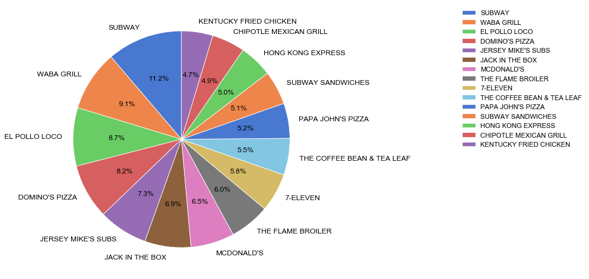

```python
fig, ax = plt.subplots(1,1, figsize=(8,10))
_ = Programs[Programs['Count'] >8e2].plot.pie(y='Count', startangle=90, legend=False,label='',ax=ax, autopct='%1.1f%%',
                   colors = sns.color_palette("muted", len(Programs[Programs['Count'] >8e2])), fontsize=12)
_ = ax.legend(bbox_to_anchor=(2, 1), fontsize=11)
```

```python
Programs_Violation  = pd.DataFrame(Data.groupby(['Program Name','Violation Code'])['Violation Code'].count())
Programs_Violation.columns = ['Count']

list = Programs[Programs['Count'] == Programs['Count'].max()].index
temp = Programs_Violation.loc[list]
temp = temp.reset_index(drop=False).drop(columns ='Program Name')
temp.T
```

|  | 0 | 1 | 2 | 3 | 4 | 5 | 6 | 7 | 8 | 9 | ... | 28 | 29 | 30 | 31 | 32 | 33 | 34 | 35 | 36 | 37 |
| --- | --- | --- | --- | --- | --- | --- | --- | --- | --- | --- | --- | --- | --- | --- | --- | --- | --- | --- | --- | --- | --- |
| Violation Code | F001 | F004 | F005 | F006 | F007 | F008 | F009 | F011 | F013 | F014 | ... | F043 | F044 | F046 | F048 | F049 | F050 | F052 | F053 | F054 | F055 |
| Count | 1 | 12 | 14 | 51 | 172 | 1 | 8 | 4 | 2 | 117 | ... | 81 | 248 | 91 | 23 | 32 | 4 | 67 | 27 | 4 | 15 |

2 rows × 38 columns

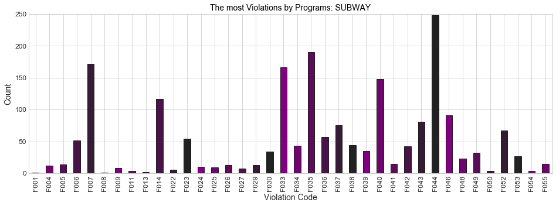

```python
fig, ax = plt.subplots(nrows=1, ncols=1, figsize=(16, 5), sharex=False)
_ = temp.plot.bar(rot=90,ax=ax, x='Violation Code', y='Count', legend=False,
                  color=sns.dark_palette("purple", reverse=True), edgecolor="k")
_ = ax.set_title('The most Violations by Programs: %s' % list.tolist()[0])
_ = ax.set_ylim([0, 2.5e2])
_ = ax.set_xlabel('Violation Code')
_ = ax.set_ylabel('Count')
```

```python
mylist=temp.sort_values('Count', ascending=False).head(3)['Violation Code'].tolist()
Violation_Dictionary_df.loc[Violation_Dictionary_df['Violation Code'].isin(mylist)].style.hide_index()
```

| Violation Code | Violation Description |
| --- | --- |
| F044 | # 44. Floors, walls and ceilings: properly built, maintained in good repair and clean |
| F035 | # 35. Equipment/Utensils - approved; installed; clean; good repair, capacity |
| F007 | # 07. Proper hot and cold holding temperatures |

## Cities with the Most Violations

```python
Facility_Cities = pd.DataFrame(Data[Data['Facility City'].isna()==False].groupby('Facility City')['Violation Code'].count())
Facility_Cities.columns = ['Count']
Facility_Cities=Facility_Cities.sort_values(by='Count', ascending=False)
list = Facility_Cities.index.tolist()
Facility_Cities.index = list
Facility_Cities[Facility_Cities['Count'] >3e3].T
```

|  | LOS ANGELES | TORRANCE | GLENDALE | NORTH HOLLYWOOD | SANTA MONICA | VAN NUYS | GARDENA | BURBANK | WHITTIER | INGLEWOOD | ... | BELL GARDENS | LAWNDALE | NORTH HILLS | LOMITA | WALNUT | SAN DIMAS | CANYON COUNTRY | LA VERNE | SANTA FE SPRINGS | TEMPLE CITY |
| --- | --- | --- | --- | --- | --- | --- | --- | --- | --- | --- | --- | --- | --- | --- | --- | --- | --- | --- | --- | --- | --- |
| Count | 281523 | 24807 | 22320 | 16805 | 16300 | 15041 | 14603 | 14533 | 13485 | 13043 | ... | 3560 | 3397 | 3362 | 3351 | 3311 | 3199 | 3189 | 3088 | 3058 | 3032 |

1 rows × 84 columns

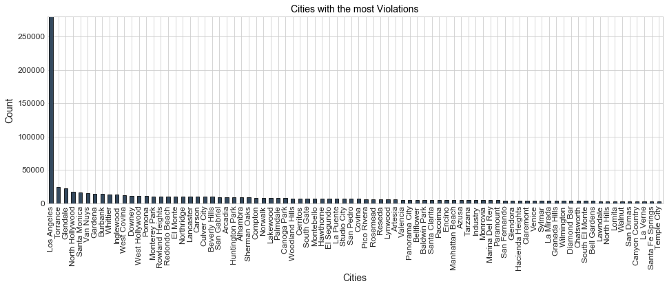

```python
fig, ax = plt.subplots(nrows=1, ncols=1, figsize=(16, 5), sharex=False)
_ = Facility_Cities[Facility_Cities['Count'] >3e3].plot.bar(ax=ax, legend=False, color='#34495e', edgecolor='k')
_ = ax.set_title('Cities with the most Violations')
_ = ax.set_ylim([0, 2.8e5])
_ = ax.set_xlabel('Cities')
_ = ax.set_ylabel('Count')
_ = ax.set_xticklabels(labels = [x.title() for x in list],rotation=90)
```

```python
Facility_Cities_Violation  = pd.DataFrame(Data.groupby(['Facility City','Violation Code'])['Violation Code'].count())
Facility_Cities_Violation.columns = ['Count']

list = Facility_Cities[Facility_Cities['Count'] == Facility_Cities['Count'].max()].index
temp = Facility_Cities_Violation.loc[list]
temp = temp.reset_index(drop=False).drop(columns ='Facility City').set_index(['Violation Code'])
temp.T
```

| Violation Code | F001 | F002 | F003 | F004 | F005 | F006 | F007 | F008 | F009 | F010 | ... | W021 | W023 | W032 | W034 | W041 | W044 | W048 | W051 | W052 | W053 |
| --- | --- | --- | --- | --- | --- | --- | --- | --- | --- | --- | --- | --- | --- | --- | --- | --- | --- | --- | --- | --- | --- |
| Count | 222 | 5 | 5 | 885 | 1218 | 11442 | 10795 | 1519 | 1941 | 2 | ... | 2 | 3 | 1 | 1 | 1 | 2 | 1 | 2 | 4 | 1 |

1 rows × 79 columns

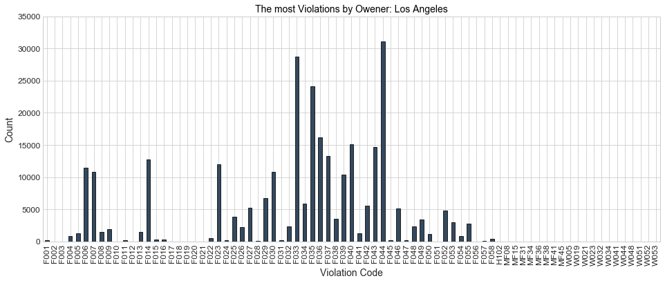

```python
fig, ax = plt.subplots(nrows=1, ncols=1, figsize=(16, 6), sharex=False)
_ = temp.plot.bar(rot=90,ax=ax, legend=False, color='#34495e', edgecolor='k')
_ = ax.set_title('The most Violations by Owener: %s' % list.tolist()[0].title())
_ = ax.set_ylim([0, 3.5e4])
_ = ax.set_xlabel('Violation Code')
_ = ax.set_ylabel('Count')
```

The most violations by this city are:

```python
mylist=temp.sort_values('Count', ascending=False).head(3).index.tolist()
Violation_Dictionary_df.loc[Violation_Dictionary_df['Violation Code'].isin(mylist)].style.hide_index()
```

| Violation Code | Violation Description |
| --- | --- |
| F044 | # 44. Floors, walls and ceilings: properly built, maintained in good repair and clean |
| F035 | # 35. Equipment/Utensils - approved; installed; clean; good repair, capacity |
| F033 | # 33. Nonfood-contact surfaces clean and in good repair |

## Service Description

```python
Service_Description = pd.DataFrame(Data[Data['Service Description'].isna()==False].groupby('Service Description')['Violation Code'].count())
Service_Description.columns = ['Count']
Service_Description.index = [x.title() for x in Service_Description.index.tolist()]
Service_Description
```

|  | Count |
| --- | --- |
| Owner Initiated Routine Inspect. | 16884 |
| Routine Inspection | 964238 |

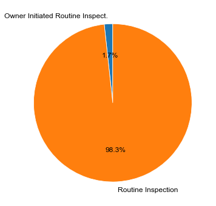

```python
_ = Service_Description.plot.pie(y='Count', startangle=90,  label='', legend=False, figsize=(6,6), autopct='%1.1f%%', fontsize=12)
```

```python
Service_Description_Violation = pd.DataFrame(Data.groupby(['Service Description','Violation Code'])['Violation Code'].count())
Service_Description_Violation.columns = ['Count']
list = Service_Description[Service_Description['Count'] == Service_Description['Count'].max()].index
temp = Service_Description_Violation.loc[list[0].upper()]
temp.T
```

| Violation Code | F001 | F002 | F003 | F004 | F005 | F006 | F007 | F008 | F009 | F010 | ... | W034 | W035 | W040 | W041 | W044 | W048 | W050 | W051 | W052 | W053 |
| --- | --- | --- | --- | --- | --- | --- | --- | --- | --- | --- | --- | --- | --- | --- | --- | --- | --- | --- | --- | --- | --- |
| Count | 406 | 34 | 34 | 3428 | 4671 | 36158 | 43042 | 5587 | 7426 | 6 | ... | 2 | 1 | 1 | 1 | 2 | 2 | 2 | 11 | 6 | 1 |

1 rows × 99 columns

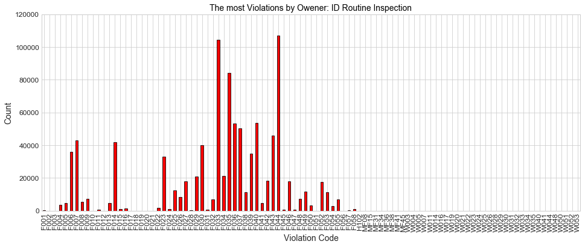

```python
fig, ax = plt.subplots(nrows=1, ncols=1, figsize=(16, 6), sharex=False)
_ = temp.plot.bar(rot=90,ax=ax, legend=False, color=sns.dark_palette("red", reverse=True), edgecolor="k")
_ = ax.set_title('The most Violations by Owener: ID %s' % list.tolist()[0])
_ = ax.set_ylim([0, 1.2e5])
_ = ax.set_xlabel('Violation Code')
_ = ax.set_ylabel('Count')
```

```python
mylist=temp.sort_values('Count', ascending=False).head(3).index.tolist()
Violation_Dictionary_df.loc[Violation_Dictionary_df['Violation Code'].isin(mylist)].style.hide_index()
```

| Violation Code | Violation Description |
| --- | --- |
| F044 | # 44. Floors, walls and ceilings: properly built, maintained in good repair and clean |
| F035 | # 35. Equipment/Utensils - approved; installed; clean; good repair, capacity |
| F033 | # 33. Nonfood-contact surfaces clean and in good repair |

## The Number of Violations by High-Score and Low-Score Facilities

```python
Score  = pd.DataFrame(Data.groupby(['Score','Facility Name'])['Violation Code'].count())
Score.columns = ['Count']
Score = Score.reset_index()
Score.head(10).style.hide_index()
```

| Score | Facility Name | Count |
| --- | --- | --- |
| 52.000000 | HOKKAIDO SEAFOOD BUFFET | 14 |
| 54.000000 | BYBY'S BAKERY | 19 |
| 54.000000 | CARSON BUFFET | 23 |
| 55.000000 | PHO KING WAY NOODLES & GRILL | 27 |
| 57.000000 | LITTLE CHILDREN NUTRITION | 21 |
| 58.000000 | BLUE LOTUS VIETNAMESE CUISINE | 24 |
| 58.000000 | LIQUORAMA | 9 |
| 59.000000 | NEW KYOTO SUSHI | 22 |
| 60.000000 | BLACK BEAR DINER | 19 |
| 60.000000 | EILAT BAKERY | 21 |

```python
Score.tail().style.hide_index()
```

| Score | Facility Name | Count |
| --- | --- | --- |
| 100.000000 | TJ MAX STORE #670 | 1 |
| 100.000000 | TOM CLARK CONFECTIONS | 3 |
| 100.000000 | TRUE FOOD KITCHEN | 1 |
| 100.000000 | YAMIBUY.COM | 2 |
| 100.000000 | ZION MARKET (MEAT DEPT) | 2 |

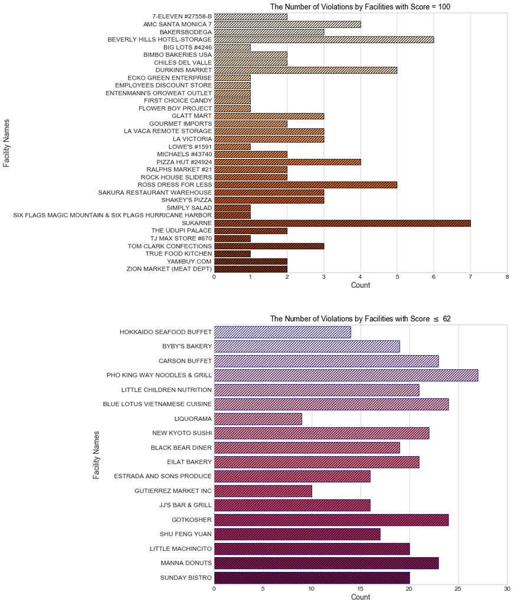

```python
fig, ax = plt.subplots(nrows=2, ncols=1, figsize=(10, 20), sharex = False)
_ = sns.barplot(ax = ax[0], y='Facility Name', x='Count', palette='Oranges',
                edgecolor='k',  hatch="/////", data = Score[Score['Score'] == Score['Score'].max()])
_ = ax[0].set_title('The Number of Violations by Facilities with Score = %i' % Score['Score'].max())
_ = ax[0].set_xlim([0, 8])
_ = ax[0].set_ylabel('Facility Names')
_ = ax[0].set_xlabel('Count')

_ = sns.barplot(ax = ax[1], y='Facility Name', x='Count', palette='Reds',
                edgecolor='Navy',  hatch="/////", data= Score[Score['Score'] <= Score['Score'].min()+10])
_ = ax[1].set_title('The Number of Violations by Facilities with Score $\leq$ %i' % (Score['Score'].min()+10))
_ = ax[1].set_xlim([0, 30])
_ = ax[1].set_ylabel('Facility Names')
_ = ax[1].set_xlabel('Count')

# plt.subplots_adjust(hspace=0.2)
```

## The Number of Violations by Each Grades

```python
Grade  = pd.DataFrame(Data.groupby(['Grade'])['Violation Code'].count())
Grade.columns = ['Count']
Grade = Grade.reset_index()
Grade.head().style.hide_index()
```

| Grade | Count |
| --- | --- |
| A | 868726 |
| B | 96012 |
| C | 14962 |

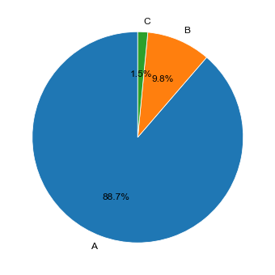

```python
_ = Grade.plot.pie(x='Grade', y='Count', labels=Grade.Grade, startangle=90, legend=False, label='',
                   figsize=(6,6), autopct='%1.1f%%', fontsize=12)
```

## Violation Status

```python
Violation_Status = pd.DataFrame(Data.groupby('Violation Status')['Violation Code'].count())
Violation_Status.columns = ['Count']
Violation_Status.T
```

| Violation Status | HOUSING NON-CRITICAL | OUT OF COMPLIANCE | VIOLATION |
| --- | --- | --- | --- |
| Count | 1 | 981179 | 4 |

## The Most Described Violations

```python
Violation_Description = pd.DataFrame(Data.groupby('Violation Description')['Violation Code'].count())
Violation_Description.columns = ['Count']
Violation_Description[Violation_Description['Count'] > 5e3]
```

| Violation Description | Count |
| --- | --- |
| # 01a. Demonstration of knowledge | 7552 |
| # 01b. Food safety certification | 17653 |
| # 06. Adequate handwashing facilities supplied & accessible | 36534 |
| # 07. Proper hot and cold holding temperatures | 44088 |
| # 08. Time as a public health control; procedures & records | 5725 |
| # 09. Proper cooling methods | 7660 |
| # 14. Food contact surfaces: clean and sanitized | 42612 |
| # 21a. Hot Water Available | 11448 |
| # 23. No rodents, insects, birds, or animals | 33811 |
| # 25. Personal cleanliness and hair restraints | 12736 |
| # 26. Approved thawing methods used, frozen food maintained frozen | 8377 |
| # 27. Food separated and protected | 18392 |
| # 29. Toxic substances properly identified, stored, used | 21365 |
| # 30. Food properly stored; food storage containers identified | 40834 |
| # 32. Food properly labeled & honestly presented | 6961 |
| # 33. Nonfood-contact surfaces clean and in good repair | 105962 |
| # 34. Warewashing facilities: Adequate, maintained, properly use, test strips available | 21602 |
| # 35. Equipment/Utensils - approved; installed; clean; good repair, capacity | 85802 |
| # 36. Equipment, utensils and linens: storage and use | 54239 |
| # 37. Adequate ventilation and lighting; designated areas, use | 51273 |
| # 38. Thermometers provided and accurate | 11454 |
| # 39. Wiping cloths: properly used and stored | 35332 |
| # 40. Plumbing: Plumbing in good repair, proper backflow devices | 54399 |
| # 42. Toilet facilities: properly constructed, supplied, cleaned | 18342 |
| # 43. Premises; personal/cleaning items; vermin-proofing | 46794 |
| # 44. Floors, walls and ceilings: properly built, maintained in good repair and clean | 108689 |
| # 46. Signs posted; last inspection report available | 18238 |
| # 47. Permits Available | 7249 |
| # 50. Impoundment of unsanitary equipment or food | 11854 |

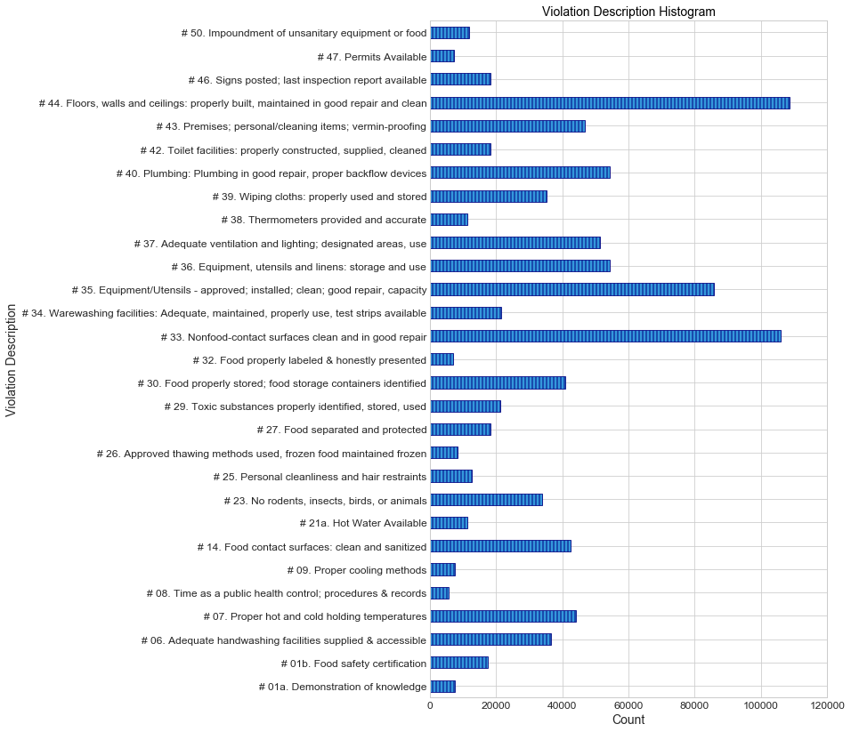

```python
fig, ax = plt.subplots(nrows=1, ncols=1, figsize=(8, 14), sharex=False)
_ = Violation_Description[Violation_Description['Count'] > 5e3].plot.barh(rot=0, legend=False,
                                                         ax=ax, color='#3498db', edgecolor='Navy', hatch = '|||')
_ = ax.set_title('Violation Description Histogram')
_ = ax.set_xlim([0, 1.2e5])
_ = ax.set_xlabel('Count')
_ = ax.set_ylabel('Violation Description')
```

## Program Element Description

```python
PE_Description_Type = pd.DataFrame(Data.groupby('PE_Type')['Violation Code'].count())
PE_Description_Type.columns = ['Count']
PE_Description_Type.T
```

| PE_Type | Caterer | Food Market Retail | Food Market Wholesale | Food Processing Wholesale | Food Vehicle Commissary | Food Warehouse | Interim Housing FF | LIC HTH Care Food FAC | Private School Cafeteria | Restaurant | Swap Meet Prepackaged Food Stand |
| --- | --- | --- | --- | --- | --- | --- | --- | --- | --- | --- | --- |
| Count | 167 | 147502 | 3 | 56 | 5 | 7 | 294 | 184 | 44 | 832859 | 1 |

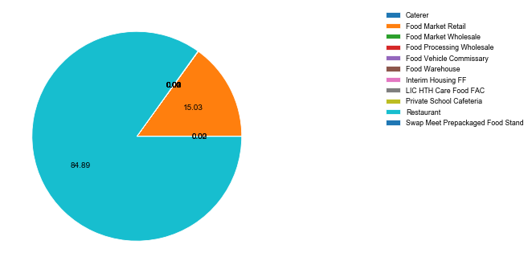

```python
fig, ax = plt.subplots(1,1, figsize=(6,6))
_ = patches, text, _ = ax.pie(PE_Description_Type['Count'].values, autopct='%.2f')
_ = ax.legend(patches, labels=PE_Description_Type.index, bbox_to_anchor=(2, 1))
```

```python
PE_Description_Risk = pd.DataFrame(Data.groupby('PE_Risk')['Violation Code'].count())
PE_Description_Risk.columns = ['Count']
PE_Description_Risk.T
```

| PE_Risk | High Risk | Low Risk | Moderate Risk |
| --- | --- | --- | --- |
| Count | 676688 | 105299 | 198558 |

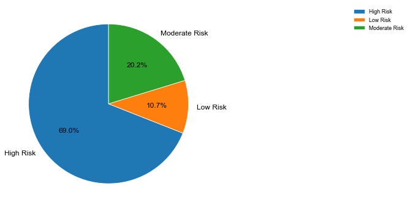

```python
fig, ax = plt.subplots(nrows=1, ncols=1, figsize=(6, 6), sharex=False)
_ = PE_Description_Risk.plot.pie(y='Count', startangle=90, legend=False,
                                 label='',ax=ax, autopct='%1.1f%%', fontsize=12)
_ = ax.legend(bbox_to_anchor=(2, 1))
```

```python
PE_Description_Seats = pd.DataFrame(Data.groupby('PE_Seats')['Violation Code'].count())
PE_Description_Seats.columns = ['Count']
PE_Description_Seats.T
```

| PE_Seats | 0-10 SQ. FT. | 0-1999 SQ. FT. | 0-30 SQ. FT. | 0-999 SQ. FT. | 1-1999 SQ. FT. | 1-4999 SQ. FT. | 1000-1999 SQ. FT. | 10000+ SQ. FT. | 151+ SQ. FT. | 2000+ SQ. FT. | 2000-3999 SQ. FT. | 2000-4999 SQ. FT. | 2000-5999 SQ. FT. | 31-60 SQ. FT. | 4000-9999 SQ. FT. | 6000+ SQ. FT. | Other |
| --- | --- | --- | --- | --- | --- | --- | --- | --- | --- | --- | --- | --- | --- | --- | --- | --- | --- |
| Count | 5 | 3 | 382524 | 76 | 102860 | 7 | 91 | 15 | 62220 | 44863 | 15 | 85 | 33 | 217638 | 151 | 11 | 110 |

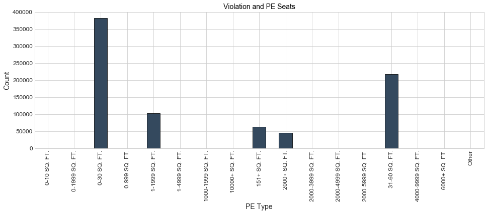

```python
fig, ax = plt.subplots(nrows=1, ncols=1, figsize=(16, 5), sharex=False)
_ = PE_Description_Seats.plot.bar(rot=90, legend=False,ax=ax, color="#34495e", edgecolor="k")
_ = ax.set_title('Violation and PE Seats')
_ = ax.set_ylim([0, 4e5])
_ = ax.set_xlabel('PE Type')
_ = ax.set_ylabel('Count')
```

## A Deeper look into Violation by each Facility

We can create a new data frame that represents all the different violations and the total number of each violation.

```python
Violations_by_Facility  = pd.DataFrame(Data.groupby(['Facility ID','Violation Code'])['Violation Code'].count())
Violations_by_Facility.columns = ['Count']
Violations_by_Facility
```

| Facility ID | Violation Code | Count |
| --- | --- | --- |
| FA0000968 | F006 | 1 |
|  | F022 | 1 |
|  | F023 | 1 |
|  | F029 | 2 |
|  | F033 | 1 |
| ... | ... | ... |
| FA0278987 | F033 | 1 |
|  | F037 | 1 |
|  | F040 | 1 |
|  | F044 | 1 |
|  | F047 | 1 |

494118 rows × 1 columns

Furthermore, we can create a matrix for violations.

```python
Violations_matrix = Violations_by_Facility['Count'].unstack(0).T
Violations_matrix.fillna(0, inplace=True)
Violations_matrix.reset_index(inplace=True)
Violations_matrix.iloc[:,1:] = Violations_matrix.iloc[:,1:].astype('int32')
Violations_matrix.head()
```

| Violation Code | Facility ID | F001 | F002 | F003 | F004 | F005 | F006 | F007 | F008 | F009 | ... | W034 | W035 | W040 | W041 | W044 | W048 | W050 | W051 | W052 | W053 |
| --- | --- | --- | --- | --- | --- | --- | --- | --- | --- | --- | --- | --- | --- | --- | --- | --- | --- | --- | --- | --- | --- |
| 0 | FA0000968 | 0 | 0 | 0 | 0 | 0 | 1 | 0 | 0 | 0 | ... | 0 | 0 | 0 | 0 | 0 | 0 | 0 | 0 | 0 | 0 |
| 1 | FA0000989 | 0 | 0 | 0 | 0 | 0 | 1 | 0 | 0 | 0 | ... | 0 | 0 | 0 | 0 | 0 | 0 | 0 | 0 | 0 | 0 |
| 2 | FA0000999 | 0 | 0 | 0 | 0 | 0 | 1 | 0 | 0 | 0 | ... | 0 | 0 | 0 | 0 | 0 | 0 | 0 | 0 | 0 | 0 |
| 3 | FA0001114 | 0 | 0 | 0 | 0 | 0 | 0 | 1 | 0 | 0 | ... | 0 | 0 | 0 | 0 | 0 | 0 | 0 | 0 | 0 | 0 |
| 4 | FA0001155 | 0 | 0 | 0 | 0 | 0 | 1 | 0 | 0 | 0 | ... | 0 | 0 | 0 | 0 | 0 | 0 | 0 | 0 | 0 | 0 |

5 rows × 100 columns

#### Saving

```python
Violations_matrix.to_csv('Data/LA/Violations_matrix_df.csv',index=False)
```

Now, we would like to know which one of these violation codes are the most correlated ones.

```python
def Correlation_Plot (Df,Fig_Size):
    Correlation_Matrix = Df.corr()
    mask = np.zeros_like(Correlation_Matrix)
    mask[np.triu_indices_from(mask)] = True
    for i in range(len(mask)):
        mask[i,i]=0
    Fig, ax = plt.subplots(figsize=(Fig_Size,Fig_Size))
    sns.heatmap(Correlation_Matrix, ax=ax, mask=mask, annot=False, square=True,
                cmap =sns.color_palette("RdYlGn", n_colors=10), linewidths = 0.01, vmin=0, vmax=1, cbar_kws={"shrink": .5})
    bottom, top = ax.get_ylim()
```

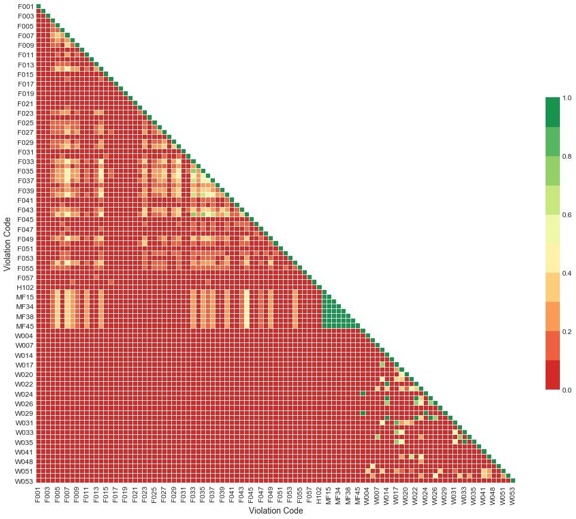

```python
Correlation_Plot(Violations_matrix, 18)
```

Let's consider those with a correlation of at least 0.6.

```python
threshold = 0.6
Correlation_Matrix = Violations_matrix.corr()
mylist=Correlation_Matrix.index.tolist()
new_list=[]
for i in mylist:
    for j in mylist:
        if (Correlation_Matrix.loc[[i],[j]].values[0,0]>=threshold) & (Correlation_Matrix.loc[[i],[j]].values[0,0]!=1):
            new_list.append(i)
            new_list.append(j)
```

```python
del list
mylist=list(set(new_list))
```

Therefore,

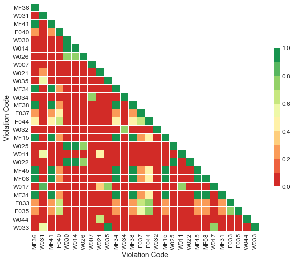

```python
Correlation_Plot(Violations_matrix[mylist], 10)
```

The most correlated codes are:

```python
print(mylist)
```

```
['MF36', 'W031', 'MF41', 'F040', 'W030', 'W014', 'W026', 'W007', 'W021', 'W035', 'MF34', 'W034', 'MF38', 'F037', 'F044', 'W032', 'MF15', 'W025', 'W011', 'W022', 'MF45', 'MF08', 'W017', 'MF31', 'F033', 'F035', 'W044', 'W033']
```